# Data Exploration for Carseat Data

We do an explorative data analysis for the Carseat Data provided by Dr. Jan Kirenz for our Applied Statistics-Project. The aim is to predict the sales of carseats.

This notebook is to explore the data, to understand the basic relationships between the variables and to get a feeling about which variables might be good predictors for the Car Sales. There will be a separate notebook containing statistical and machine learning models for the predictions.

Author: Julia Hammerer, Vanessa Mai  
Last Changes: 18.11.2018

```python
import sys
sys.path.insert(0, '../helper/')
```

```python
# load packages
%matplotlib inline
import numpy as np
import pandas as pd
import seaborn as sns
import pandas_profiling
import missingno as msno
import matplotlib.pyplot as plt
import plotly.graph_objs as go
import warnings
import math

from pandas.tools.plotting import table
from plotly.offline import init_notebook_mode
from plotly.offline import iplot
from plotly.offline import plot
from scipy.stats import mannwhitneyu
from statsmodels.distributions.empirical_distribution import ECDF
from scipy import stats
from scipy.stats import pearsonr
from scipy.stats import norm

from helper import na_ratio_table
from helper import corr_heatmap
from helper import corr_matrix_1
```

[output not shown]

[output cut: 29 more lines]

[output not shown]

```python
#load data in dataframe
df = pd.read_csv("../data/Carseats.csv")
```

```python
df.head()
```

|  | Unnamed: 0 | Sales | CompPrice | Income | Advertising | Population | Price | ShelveLoc | Age | Education | Urban | US |
| --- | --- | --- | --- | --- | --- | --- | --- | --- | --- | --- | --- | --- |
| 0 | 1 | 9.50 | 138 | 73 | 11 | 276 | 120 | Bad | 42 | 17 | Yes | Yes |
| 1 | 2 | 11.22 | 111 | 48 | 16 | 260 | 83 | Good | 65 | 10 | Yes | Yes |
| 2 | 3 | 10.06 | 113 | 35 | 10 | 269 | 80 | Medium | 59 | 12 | Yes | Yes |
| 3 | 4 | 7.40 | 117 | 100 | 4 | 466 | 97 | Medium | 55 | 14 | Yes | Yes |
| 4 | 5 | 4.15 | 141 | 64 | 3 | 340 | 128 | Bad | 38 | 13 | Yes | No |

```python
#drop useless columns
df = df.drop(columns=["Unnamed: 0"])
```

```python
print("Number of records and variables: ",df.shape)
```

```
Number of records and variables:  (400, 11)
```

Overview

Dataset info

| Number of variables | 11 |
| --- | --- |
| Number of observations | 400 |
| Total Missing (%) | 0.0% |
| Total size in memory | 34.5 KiB |
| Average record size in memory | 88.2 B |

Variables types

| Numeric | 8 |
| --- | --- |
| Categorical | 3 |
| Boolean | 0 |
| Date | 0 |
| Text (Unique) | 0 |
| Rejected | 0 |
| Unsupported | 0 |

Warnings

- `Advertising` has 144 / 36.0% zeros Zeros

Variables

Advertising  
Numeric

| Distinct count | 28 |
| --- | --- |
| Unique (%) | 7.0% |
| Missing (%) | 0.0% |
| Missing (n) | 0 |
| Infinite (%) | 0.0% |
| Infinite (n) | 0 |

| Mean | 6.635 |
| --- | --- |
| Minimum | 0 |
| Maximum | 29 |
| Zeros (%) | 36.0% |

Toggle details

**Statistics**

Quantile statistics

| Minimum | 0 |
| --- | --- |
| 5-th percentile | 0 |
| Q1 | 0 |
| Median | 5 |
| Q3 | 12 |
| 95-th percentile | 19 |
| Maximum | 29 |
| Range | 29 |
| Interquartile range | 12 |

Descriptive statistics

| Standard deviation | 6.6504 |
| --- | --- |
| Coef of variation | 1.0023 |
| Kurtosis | -0.54512 |
| Mean | 6.635 |
| MAD | 5.8013 |
| Skewness | 0.63959 |
| Sum | 2654 |
| Variance | 44.227 |
| Memory size | 3.2 KiB |

**Histogram**

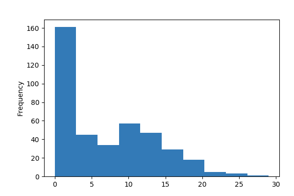

**Common Values**

| Value | Count | Frequency (%) |  |
| --- | --- | --- | --- |
| 0 | 144 | 36.0% |  |
| 10 | 25 | 6.2% |  |
| 11 | 22 | 5.5% |  |
| 13 | 20 | 5.0% |  |
| 5 | 19 | 4.8% |  |
| 7 | 16 | 4.0% |  |
| 12 | 16 | 4.0% |  |
| 3 | 14 | 3.5% |  |
| 15 | 12 | 3.0% |  |
| 4 | 12 | 3.0% |  |
| Other values (18) | 100 | 25.0% |  |

**Extreme Values**

Minimum 5 values

| Value | Count | Frequency (%) |  |
| --- | --- | --- | --- |
| 0 | 144 | 36.0% |  |
| 1 | 8 | 2.0% |  |
| 2 | 9 | 2.2% |  |
| 3 | 14 | 3.5% |  |
| 4 | 12 | 3.0% |  |

Maximum 5 values

| Value | Count | Frequency (%) |  |
| --- | --- | --- | --- |
| 23 | 2 | 0.5% |  |
| 24 | 1 | 0.2% |  |
| 25 | 1 | 0.2% |  |
| 26 | 1 | 0.2% |  |
| 29 | 1 | 0.2% |  |

Age  
Numeric

| Distinct count | 56 |
| --- | --- |
| Unique (%) | 14.0% |
| Missing (%) | 0.0% |
| Missing (n) | 0 |
| Infinite (%) | 0.0% |
| Infinite (n) | 0 |

| Mean | 53.322 |
| --- | --- |
| Minimum | 25 |
| Maximum | 80 |
| Zeros (%) | 0.0% |

Toggle details

**Statistics**

Quantile statistics

| Minimum | 25 |
| --- | --- |
| 5-th percentile | 27 |
| Q1 | 39.75 |
| Median | 54.5 |
| Q3 | 66 |
| 95-th percentile | 79 |
| Maximum | 80 |
| Range | 55 |
| Interquartile range | 26.25 |

Descriptive statistics

| Standard deviation | 16.2 |
| --- | --- |
| Coef of variation | 0.30382 |
| Kurtosis | -1.1344 |
| Mean | 53.322 |
| MAD | 13.905 |
| Skewness | -0.077182 |
| Sum | 21329 |
| Variance | 262.45 |
| Memory size | 3.2 KiB |

**Histogram**

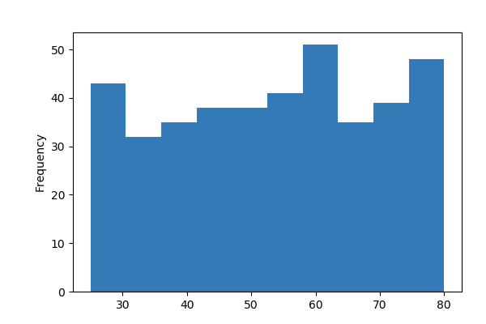

**Common Values**

| Value | Count | Frequency (%) |  |
| --- | --- | --- | --- |
| 62 | 14 | 3.5% |  |
| 80 | 13 | 3.2% |  |
| 61 | 12 | 3.0% |  |
| 76 | 11 | 2.8% |  |
| 65 | 10 | 2.5% |  |
| 45 | 10 | 2.5% |  |
| 73 | 10 | 2.5% |  |
| 55 | 10 | 2.5% |  |
| 64 | 10 | 2.5% |  |
| 34 | 9 | 2.2% |  |
| Other values (46) | 291 | 72.8% |  |

**Extreme Values**

Minimum 5 values

| Value | Count | Frequency (%) |  |
| --- | --- | --- | --- |
| 25 | 9 | 2.2% |  |
| 26 | 8 | 2.0% |  |
| 27 | 6 | 1.5% |  |
| 28 | 7 | 1.8% |  |
| 29 | 7 | 1.8% |  |

Maximum 5 values

| Value | Count | Frequency (%) |  |
| --- | --- | --- | --- |
| 76 | 11 | 2.8% |  |
| 77 | 6 | 1.5% |  |
| 78 | 4 | 1.0% |  |
| 79 | 8 | 2.0% |  |
| 80 | 13 | 3.2% |  |

CompPrice  
Numeric

| Distinct count | 73 |
| --- | --- |
| Unique (%) | 18.2% |
| Missing (%) | 0.0% |
| Missing (n) | 0 |
| Infinite (%) | 0.0% |
| Infinite (n) | 0 |

| Mean | 124.97 |
| --- | --- |
| Minimum | 77 |
| Maximum | 175 |
| Zeros (%) | 0.0% |

Toggle details

**Statistics**

Quantile statistics

| Minimum | 77 |
| --- | --- |
| 5-th percentile | 98 |
| Q1 | 115 |
| Median | 125 |
| Q3 | 135 |
| 95-th percentile | 150 |
| Maximum | 175 |
| Range | 98 |
| Interquartile range | 20 |

Descriptive statistics

| Standard deviation | 15.335 |
| --- | --- |
| Coef of variation | 0.1227 |
| Kurtosis | 0.041666 |
| Mean | 124.97 |
| MAD | 12.215 |
| Skewness | -0.042755 |
| Sum | 49990 |
| Variance | 235.15 |
| Memory size | 3.2 KiB |

**Histogram**

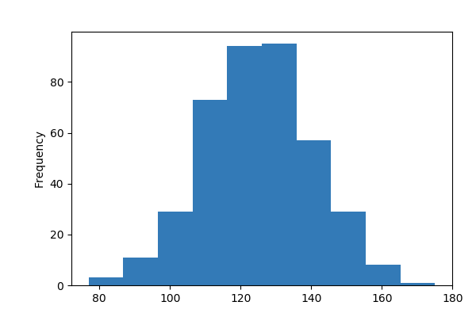

**Common Values**

| Value | Count | Frequency (%) |  |
| --- | --- | --- | --- |
| 121 | 16 | 4.0% |  |
| 131 | 14 | 3.5% |  |
| 122 | 14 | 3.5% |  |
| 123 | 13 | 3.2% |  |
| 115 | 12 | 3.0% |  |
| 130 | 12 | 3.0% |  |
| 132 | 12 | 3.0% |  |
| 134 | 11 | 2.8% |  |
| 116 | 11 | 2.8% |  |
| 125 | 11 | 2.8% |  |
| Other values (63) | 274 | 68.5% |  |

**Extreme Values**

Minimum 5 values

| Value | Count | Frequency (%) |  |
| --- | --- | --- | --- |
| 77 | 1 | 0.2% |  |
| 85 | 1 | 0.2% |  |
| 86 | 1 | 0.2% |  |
| 88 | 1 | 0.2% |  |
| 89 | 2 | 0.5% |  |

Maximum 5 values

| Value | Count | Frequency (%) |  |
| --- | --- | --- | --- |
| 157 | 2 | 0.5% |  |
| 159 | 2 | 0.5% |  |
| 161 | 1 | 0.2% |  |
| 162 | 2 | 0.5% |  |
| 175 | 1 | 0.2% |  |

Education  
Numeric

| Distinct count | 9 |
| --- | --- |
| Unique (%) | 2.2% |
| Missing (%) | 0.0% |
| Missing (n) | 0 |
| Infinite (%) | 0.0% |
| Infinite (n) | 0 |

| Mean | 13.9 |
| --- | --- |
| Minimum | 10 |
| Maximum | 18 |
| Zeros (%) | 0.0% |

Toggle details

**Statistics**

Quantile statistics

| Minimum | 10 |
| --- | --- |
| 5-th percentile | 10 |
| Q1 | 12 |
| Median | 14 |
| Q3 | 16 |
| 95-th percentile | 18 |
| Maximum | 18 |
| Range | 8 |
| Interquartile range | 4 |

Descriptive statistics

| Standard deviation | 2.6205 |
| --- | --- |
| Coef of variation | 0.18853 |
| Kurtosis | -1.2983 |
| Mean | 13.9 |
| MAD | 2.291 |
| Skewness | 0.044007 |
| Sum | 5560 |
| Variance | 6.8672 |
| Memory size | 3.2 KiB |

**Histogram**

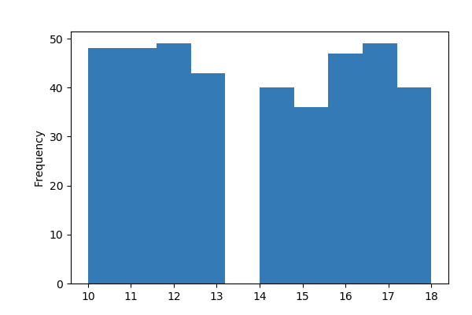

**Common Values**

| Value | Count | Frequency (%) |  |
| --- | --- | --- | --- |
| 17 | 49 | 12.2% |  |
| 12 | 49 | 12.2% |  |
| 11 | 48 | 12.0% |  |
| 10 | 48 | 12.0% |  |
| 16 | 47 | 11.8% |  |
| 13 | 43 | 10.8% |  |
| 18 | 40 | 10.0% |  |
| 14 | 40 | 10.0% |  |
| 15 | 36 | 9.0% |  |

**Extreme Values**

Minimum 5 values

| Value | Count | Frequency (%) |  |
| --- | --- | --- | --- |
| 10 | 48 | 12.0% |  |
| 11 | 48 | 12.0% |  |
| 12 | 49 | 12.2% |  |
| 13 | 43 | 10.8% |  |
| 14 | 40 | 10.0% |  |

Maximum 5 values

| Value | Count | Frequency (%) |  |
| --- | --- | --- | --- |
| 14 | 40 | 10.0% |  |
| 15 | 36 | 9.0% |  |
| 16 | 47 | 11.8% |  |
| 17 | 49 | 12.2% |  |
| 18 | 40 | 10.0% |  |

Income  
Numeric

| Distinct count | 98 |
| --- | --- |
| Unique (%) | 24.5% |
| Missing (%) | 0.0% |
| Missing (n) | 0 |
| Infinite (%) | 0.0% |
| Infinite (n) | 0 |

| Mean | 68.657 |
| --- | --- |
| Minimum | 21 |
| Maximum | 120 |
| Zeros (%) | 0.0% |

Toggle details

**Statistics**

Quantile statistics

| Minimum | 21 |
| --- | --- |
| 5-th percentile | 26 |
| Q1 | 42.75 |
| Median | 69 |
| Q3 | 91 |
| 95-th percentile | 115 |
| Maximum | 120 |
| Range | 99 |
| Interquartile range | 48.25 |

Descriptive statistics

| Standard deviation | 27.986 |
| --- | --- |
| Coef of variation | 0.40762 |
| Kurtosis | -1.0853 |
| Mean | 68.657 |
| MAD | 23.641 |
| Skewness | 0.049444 |
| Sum | 27463 |
| Variance | 783.22 |
| Memory size | 3.2 KiB |

**Histogram**

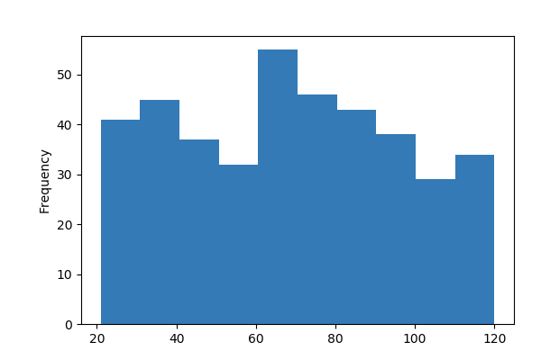

**Common Values**

| Value | Count | Frequency (%) |  |
| --- | --- | --- | --- |
| 69 | 11 | 2.8% |  |
| 42 | 10 | 2.5% |  |
| 32 | 8 | 2.0% |  |
| 100 | 8 | 2.0% |  |
| 60 | 7 | 1.8% |  |
| 84 | 7 | 1.8% |  |
| 93 | 7 | 1.8% |  |
| 33 | 7 | 1.8% |  |
| 67 | 7 | 1.8% |  |
| 73 | 7 | 1.8% |  |
| Other values (88) | 321 | 80.2% |  |

**Extreme Values**

Minimum 5 values

| Value | Count | Frequency (%) |  |
| --- | --- | --- | --- |
| 21 | 4 | 1.0% |  |
| 22 | 4 | 1.0% |  |
| 23 | 1 | 0.2% |  |
| 24 | 4 | 1.0% |  |
| 25 | 6 | 1.5% |  |

Maximum 5 values

| Value | Count | Frequency (%) |  |
| --- | --- | --- | --- |
| 116 | 1 | 0.2% |  |
| 117 | 6 | 1.5% |  |
| 118 | 4 | 1.0% |  |
| 119 | 4 | 1.0% |  |
| 120 | 4 | 1.0% |  |

Population  
Numeric

| Distinct count | 275 |
| --- | --- |
| Unique (%) | 68.8% |
| Missing (%) | 0.0% |
| Missing (n) | 0 |
| Infinite (%) | 0.0% |
| Infinite (n) | 0 |

| Mean | 264.84 |
| --- | --- |
| Minimum | 10 |
| Maximum | 509 |
| Zeros (%) | 0.0% |

Toggle details

**Statistics**

Quantile statistics

| Minimum | 10 |
| --- | --- |
| 5-th percentile | 29 |
| Q1 | 139 |
| Median | 272 |
| Q3 | 398.5 |
| 95-th percentile | 493.15 |
| Maximum | 509 |
| Range | 499 |
| Interquartile range | 259.5 |

Descriptive statistics

| Standard deviation | 147.38 |
| --- | --- |
| Coef of variation | 0.55647 |
| Kurtosis | -1.2023 |
| Mean | 264.84 |
| MAD | 127.17 |
| Skewness | -0.051227 |
| Sum | 105936 |
| Variance | 21720 |
| Memory size | 3.2 KiB |

**Histogram**

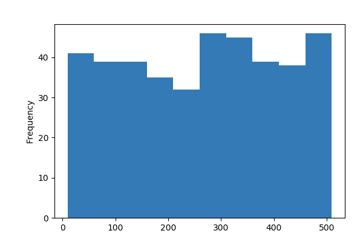

**Common Values**

| Value | Count | Frequency (%) |  |
| --- | --- | --- | --- |
| 170 | 4 | 1.0% |  |
| 148 | 4 | 1.0% |  |
| 220 | 4 | 1.0% |  |
| 125 | 4 | 1.0% |  |
| 237 | 4 | 1.0% |  |
| 497 | 4 | 1.0% |  |
| 276 | 4 | 1.0% |  |
| 27 | 3 | 0.8% |  |
| 284 | 3 | 0.8% |  |
| 60 | 3 | 0.8% |  |
| Other values (265) | 363 | 90.8% |  |

**Extreme Values**

Minimum 5 values

| Value | Count | Frequency (%) |  |
| --- | --- | --- | --- |
| 10 | 1 | 0.2% |  |
| 12 | 1 | 0.2% |  |
| 13 | 1 | 0.2% |  |
| 14 | 1 | 0.2% |  |
| 16 | 2 | 0.5% |  |

Maximum 5 values

| Value | Count | Frequency (%) |  |
| --- | --- | --- | --- |
| 503 | 1 | 0.2% |  |
| 504 | 1 | 0.2% |  |
| 507 | 1 | 0.2% |  |
| 508 | 2 | 0.5% |  |
| 509 | 1 | 0.2% |  |

Price  
Numeric

| Distinct count | 101 |
| --- | --- |
| Unique (%) | 25.2% |
| Missing (%) | 0.0% |
| Missing (n) | 0 |
| Infinite (%) | 0.0% |
| Infinite (n) | 0 |

| Mean | 115.8 |
| --- | --- |
| Minimum | 24 |
| Maximum | 191 |
| Zeros (%) | 0.0% |

Toggle details

**Statistics**

Quantile statistics

| Minimum | 24 |
| --- | --- |
| 5-th percentile | 77 |
| Q1 | 100 |
| Median | 117 |
| Q3 | 131 |
| 95-th percentile | 155.05 |
| Maximum | 191 |
| Range | 167 |
| Interquartile range | 31 |

Descriptive statistics

| Standard deviation | 23.677 |
| --- | --- |
| Coef of variation | 0.20447 |
| Kurtosis | 0.45189 |
| Mean | 115.8 |
| MAD | 18.756 |
| Skewness | -0.12529 |
| Sum | 46318 |
| Variance | 560.58 |
| Memory size | 3.2 KiB |

**Histogram**

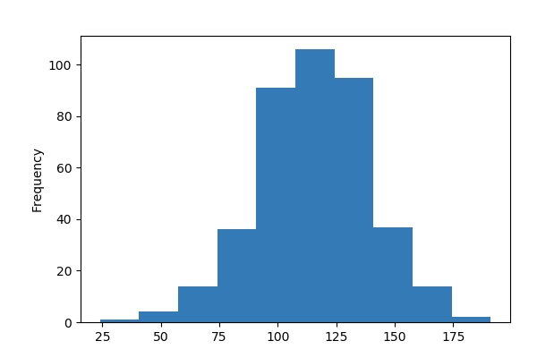

**Common Values**

| Value | Count | Frequency (%) |  |
| --- | --- | --- | --- |
| 128 | 12 | 3.0% |  |
| 120 | 12 | 3.0% |  |
| 104 | 10 | 2.5% |  |
| 131 | 10 | 2.5% |  |
| 107 | 10 | 2.5% |  |
| 129 | 9 | 2.2% |  |
| 132 | 9 | 2.2% |  |
| 118 | 9 | 2.2% |  |
| 110 | 9 | 2.2% |  |
| 112 | 9 | 2.2% |  |
| Other values (91) | 301 | 75.2% |  |

**Extreme Values**

Minimum 5 values

| Value | Count | Frequency (%) |  |
| --- | --- | --- | --- |
| 24 | 1 | 0.2% |  |
| 49 | 1 | 0.2% |  |
| 53 | 1 | 0.2% |  |
| 54 | 1 | 0.2% |  |
| 55 | 1 | 0.2% |  |

Maximum 5 values

| Value | Count | Frequency (%) |  |
| --- | --- | --- | --- |
| 166 | 2 | 0.5% |  |
| 171 | 1 | 0.2% |  |
| 173 | 1 | 0.2% |  |
| 185 | 1 | 0.2% |  |
| 191 | 1 | 0.2% |  |

Sales  
Numeric

| Distinct count | 336 |
| --- | --- |
| Unique (%) | 84.0% |
| Missing (%) | 0.0% |
| Missing (n) | 0 |
| Infinite (%) | 0.0% |
| Infinite (n) | 0 |

| Mean | 7.4963 |
| --- | --- |
| Minimum | 0 |
| Maximum | 16.27 |
| Zeros (%) | 0.2% |

Toggle details

**Statistics**

Quantile statistics

| Minimum | 0 |
| --- | --- |
| 5-th percentile | 3.149 |
| Q1 | 5.39 |
| Median | 7.49 |
| Q3 | 9.32 |
| 95-th percentile | 12.442 |
| Maximum | 16.27 |
| Range | 16.27 |
| Interquartile range | 3.93 |

Descriptive statistics

| Standard deviation | 2.8241 |
| --- | --- |
| Coef of variation | 0.37673 |
| Kurtosis | -0.080877 |
| Mean | 7.4963 |
| MAD | 2.2622 |
| Skewness | 0.18556 |
| Sum | 2998.5 |
| Variance | 7.9756 |
| Memory size | 3.2 KiB |

**Histogram**

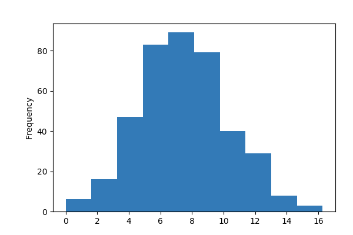

**Common Values**

| Value | Count | Frequency (%) |  |
| --- | --- | --- | --- |
| 7.8 | 4 | 1.0% |  |
| 6.67 | 3 | 0.8% |  |
| 8.77 | 3 | 0.8% |  |
| 9.32 | 3 | 0.8% |  |
| 5.87 | 3 | 0.8% |  |
| 6.53 | 3 | 0.8% |  |
| 6.88 | 3 | 0.8% |  |
| 6.2 | 3 | 0.8% |  |
| 4.1 | 3 | 0.8% |  |
| 5.58 | 2 | 0.5% |  |
| Other values (326) | 370 | 92.5% |  |

**Extreme Values**

Minimum 5 values

| Value | Count | Frequency (%) |  |
| --- | --- | --- | --- |
| 0.0 | 1 | 0.2% |  |
| 0.16 | 1 | 0.2% |  |
| 0.37 | 1 | 0.2% |  |
| 0.53 | 1 | 0.2% |  |
| 0.91 | 1 | 0.2% |  |

Maximum 5 values

| Value | Count | Frequency (%) |  |
| --- | --- | --- | --- |
| 13.91 | 1 | 0.2% |  |
| 14.37 | 1 | 0.2% |  |
| 14.9 | 1 | 0.2% |  |
| 15.63 | 1 | 0.2% |  |
| 16.27 | 1 | 0.2% |  |

ShelveLoc  
Categorical

| Distinct count | 3 |
| --- | --- |
| Unique (%) | 0.8% |
| Missing (%) | 0.0% |
| Missing (n) | 0 |

| Medium | 219 |
| --- | --- |
| Bad | 96 |
| Good | 85 |

Toggle details

| Value | Count | Frequency (%) |  |
| --- | --- | --- | --- |
| Medium | 219 | 54.8% |  |
| Bad | 96 | 24.0% |  |
| Good | 85 | 21.2% |  |

US  
Categorical

| Distinct count | 2 |
| --- | --- |
| Unique (%) | 0.5% |
| Missing (%) | 0.0% |
| Missing (n) | 0 |

| Yes | 258 |
| --- | --- |
| No | 142 |

Toggle details

| Value | Count | Frequency (%) |  |
| --- | --- | --- | --- |
| Yes | 258 | 64.5% |  |
| No | 142 | 35.5% |  |

Urban  
Categorical

| Distinct count | 2 |
| --- | --- |
| Unique (%) | 0.5% |
| Missing (%) | 0.0% |
| Missing (n) | 0 |

| Yes | 282 |
| --- | --- |
| No | 118 |

Toggle details

| Value | Count | Frequency (%) |  |
| --- | --- | --- | --- |
| Yes | 282 | 70.5% |  |
| No | 118 | 29.5% |  |

Correlations

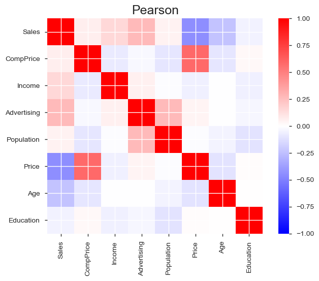

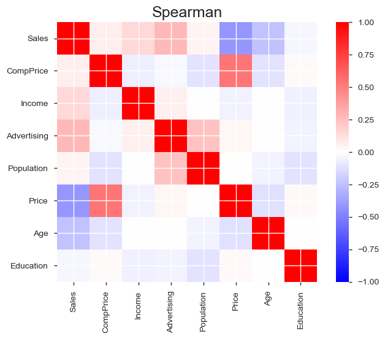

Sample

|  | Sales | CompPrice | Income | Advertising | Population | Price | ShelveLoc | Age | Education | Urban | US |
| --- | --- | --- | --- | --- | --- | --- | --- | --- | --- | --- | --- |
| 0 | 9.50 | 138 | 73 | 11 | 276 | 120 | Bad | 42 | 17 | Yes | Yes |
| 1 | 11.22 | 111 | 48 | 16 | 260 | 83 | Good | 65 | 10 | Yes | Yes |
| 2 | 10.06 | 113 | 35 | 10 | 269 | 80 | Medium | 59 | 12 | Yes | Yes |
| 3 | 7.40 | 117 | 100 | 4 | 466 | 97 | Medium | 55 | 14 | Yes | Yes |
| 4 | 4.15 | 141 | 64 | 3 | 340 | 128 | Bad | 38 | 13 | Yes | No |

```python
pandas_profiling.ProfileReport(df)
```

## We take a look at the Variables

We have 11 variables, of which 8 are numeric and 3 are categorical. The total missing is 0%.

Sales - Unit sales (in thousands) at each location

CompPrice - Price charged by competitor at each location

Income - Community income level (in thousands of dollars)

Advertising - Local advertising budget for company at each location (in thousands of dollars)

Population - Population size in region (in thousands)

Price - Price company charges for car seats at each site

ShelveLoc - A factor with levels Bad, Good and Medium indicating the quality of the shelving location for the car seats at each site

Age - Average age of the local population

Education - Education level at each location

Urban - A factor with levels No and Yes to indicate whether the store is in an urban or rural location

US - A factor with levels No and Yes to indicate whether the store is in the US or not

In General, the overall quality is very well. The data do not contain any missingness and are evenly distributed. We can see that the Advertising column has a high number of zeros. This could either be a sign of bad data quality or there was no budget for advertisement. As the dataset is well maintained we think that option 2 is correct.

```python
df.isnull().sum()
```

```
Sales          0
CompPrice      0
Income         0
Advertising    0
Population     0
Price          0
ShelveLoc      0
Age            0
Education      0
Urban          0
US             0
dtype: int64
```

```python
df.dtypes
```

```
Sales          float64
CompPrice        int64
Income           int64
Advertising      int64
Population       int64
Price            int64
ShelveLoc       object
Age              int64
Education        int64
Urban           object
US              object
dtype: object
```

```python
#check for duplicates
df[df.duplicated(keep=False)]
```

|  | Sales | CompPrice | Income | Advertising | Population | Price | ShelveLoc | Age | Education | Urban | US |
| --- | --- | --- | --- | --- | --- | --- | --- | --- | --- | --- | --- |

```python
#select columns with numeric datatypes
df_num = df.select_dtypes(include=["float64","int64"])
```

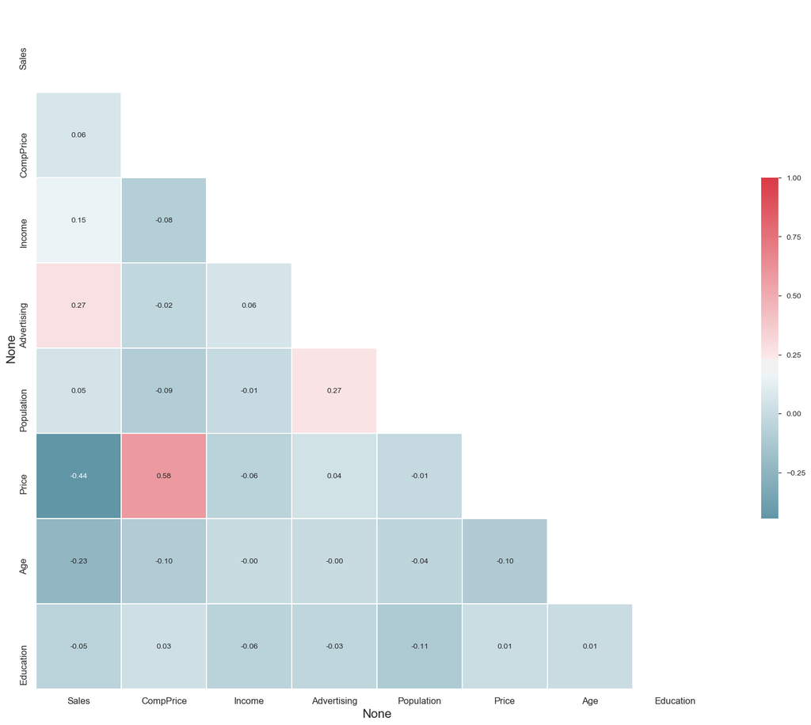

```python
#plot correlation for numeric columns
df_corr=df_num.corr()
corr_heatmap(df_corr, figsize=(20, 16))
```

In the correlation matrix we see that Price and CompPrice highly positively correlate. Also we see that Sales and Advertisement correlates. Advertisement also correlates with Population. Highly negatively correlates Sales with Price, which makes sense.

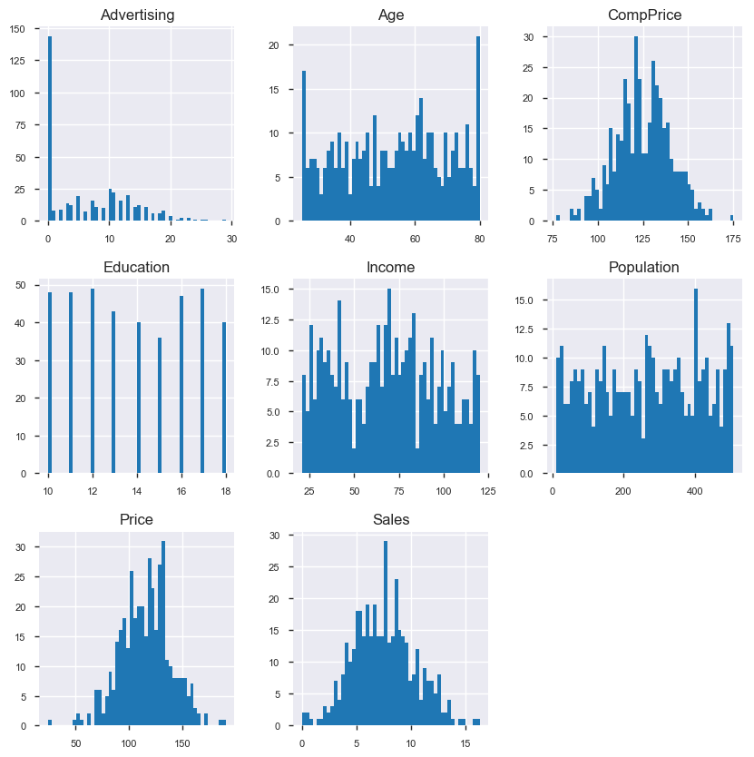

```python
df_num.hist(figsize=(10,10),bins=50, xlabelsize=8, ylabelsize=8);
```

We check the histogram of the numeric vaiables. Except of the many zeros in Advertisment we can't see any abnormal behaviour of the data.

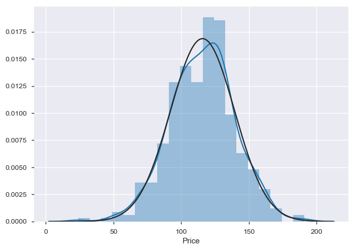

```python
sns.distplot(df.Price, fit=norm,);
```

We see that the Price is close but not completely normally distributed so we have a deeper look with the Probability Plot.

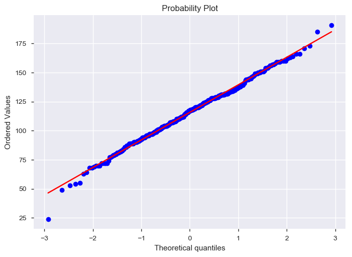

```python
stats.probplot(df['Price'], plot=plt);
```

Price is actually quite normally distributed except of a few outliers, especially one in the down left corner

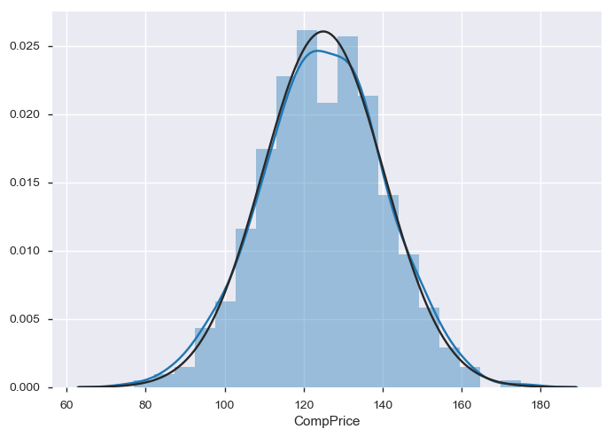

```python
sns.distplot(df.CompPrice, fit=norm);
```

In comparison to the the Price, the CompPrice is not skewed and almost perfectly normal distributed.

### Data Engineering

To get a better understanding of the data we have a deeper look at the Sales variable.

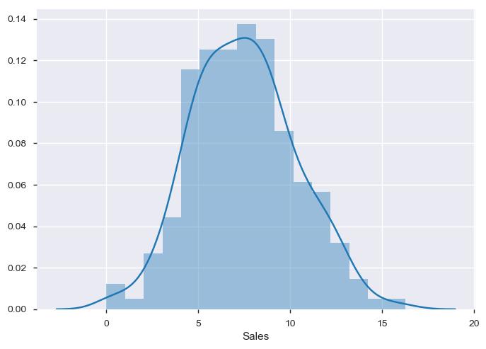

```python
sns.distplot(df.Sales);
```

```python
df["Sales"].describe()
```

```
count    400.000000
mean       7.496325
std        2.824115
min        0.000000
25%        5.390000
50%        7.490000
75%        9.320000
max       16.270000
Name: Sales, dtype: float64
```

We want to see if we can predict the sales. Therefore we create a new variable called "Target" with the values "Yes" and "No". If the Sales are above the median, the target is reached otherwise it is not.

```python
df["Sales"].median()
```

```
7.49
```

```python
def Sales_target(row):
    if row["Sales"]<=7.49:
        return "No"
    else:
        return "Yes"


df["Target"]= df.apply(lambda row: Sales_target(row), axis=1)
```

```python
df.head()
```

|  | Sales | CompPrice | Income | Advertising | Population | Price | ShelveLoc | Age | Education | Urban | US | Target |
| --- | --- | --- | --- | --- | --- | --- | --- | --- | --- | --- | --- | --- |
| 0 | 9.50 | 138 | 73 | 11 | 276 | 120 | Bad | 42 | 17 | Yes | Yes | Yes |
| 1 | 11.22 | 111 | 48 | 16 | 260 | 83 | Good | 65 | 10 | Yes | Yes | Yes |
| 2 | 10.06 | 113 | 35 | 10 | 269 | 80 | Medium | 59 | 12 | Yes | Yes | Yes |
| 3 | 7.40 | 117 | 100 | 4 | 466 | 97 | Medium | 55 | 14 | Yes | Yes | No |
| 4 | 4.15 | 141 | 64 | 3 | 340 | 128 | Bad | 38 | 13 | Yes | No | No |

## Summary

We can already spot some correlations between various attributes. E.g.

- Price and CompPrice
- Sales and Advertisement
- Sales and Price

This means that Advertisement and Price might be high influences on the Sales.

We will take a look at these attributes in later analysis.

For the defined classes we will try to apply some classification methods. These classes are quite arbitrary defined and the only purpose is for us to try some classification models.